# Advanced Statistical Inference 2017/2018 Assessed Exercise

# Content Table

I. Importing Libraries and notebook adjustment  
II. Loading Data  
1. MNIST Dataset  
2. CIFAR10 Dataset  
III. Data visualisation and statistics  
0. Implemented functions  
1. MNIST Dataset  
2. CIFAR10 Dataset  
IV. Naïve Bayes Classifier  
1. Implementation  
2. Application to Fashion MNIST dataset  
3. Application to CIFAR10 dataset  
4. Confusion Matrix  
4. Performance analysis  
V. Bayesian Linear Regression  
1. Implementation  
2. Application to Fashion MNIST dataset  
3. Application to CIFAR10 dataset  
4. Scatter Plot  
5. Confusion Matrix  
VI. Bonus question  
1. MNIST dataset: CNN output  
2. Applying Naive Bayes

# Go to Text Answers

**Question 2**  
Comment on the distribution of class labels and the dimensionality of the input and how these may affect the analysis.  
**Question 3.b**  
Describe a positive and a negative feature of the classifier for these tasks.  
**Question 3.c**  
Describe any data pre-processing that you suggest for this data and your classifier  
**Question 3.f**  
Discuss the performance, compare them against a classifier that outputs random class labels, and suggest ways in which performance could be improved  
**Question 4.d**  
Suggest a way to discretize predictions and display the confusion matrix on the test data and report accuracy  
**Question 4.e**  
Discuss regression performance with respect to classification performance  
**Question 4.f**  
Describe one limitation of using regression for this particular task

# I. Importing Libraries and notebook adjustment Go to content Table

```python
import numpy as np
import pandas as pd
import matplotlib
import seaborn as sns
import random
import matplotlib.pyplot as plt
from matplotlib.gridspec import GridSpec
from sklearn.metrics import confusion_matrix, log_loss, accuracy_score
%matplotlib inline
from numpy import genfromtxt

import warnings
warnings.filterwarnings('ignore')
```

```python
%%html
#center the figures in the notebook
<style>
.output_png {
    display: table-cell;
    text-align: center;
    vertical-align: middle;
}
</style>
```

#center the figures in the notebook

# II. Loading data Go to content Table

### Data sources:

In this work you will analyze the Fashion MNIST and CIFAR10 datasets available to download from:  
https://www.kaggle.com/zalando-research/fashionmnist/data  
https://www.cs.toronto.edu/~kriz/cifar.html

### II.1 MNIST dataset Go to content Table

### Uploading the data

```python
mnist_train_path="./fashion-mnist_train.csv"
mnist_test_path="./fashion-mnist_test.csv"
```

```python
# uploading the data into a DataFrame
mnist_train_pd=pd.read_csv(mnist_train_path)
mnist_test_pd=pd.read_csv(mnist_test_path)

#an overview of the data
mnist_train_pd.head(10)
```

|  | label | pixel1 | pixel2 | pixel3 | pixel4 | pixel5 | pixel6 | pixel7 | pixel8 | pixel9 | ... | pixel775 | pixel776 | pixel777 | pixel778 | pixel779 | pixel780 | pixel781 | pixel782 | pixel783 | pixel784 |
| --- | --- | --- | --- | --- | --- | --- | --- | --- | --- | --- | --- | --- | --- | --- | --- | --- | --- | --- | --- | --- | --- |
| 0 | 2 | 0 | 0 | 0 | 0 | 0 | 0 | 0 | 0 | 0 | ... | 0 | 0 | 0 | 0 | 0 | 0 | 0 | 0 | 0 | 0 |
| 1 | 9 | 0 | 0 | 0 | 0 | 0 | 0 | 0 | 0 | 0 | ... | 0 | 0 | 0 | 0 | 0 | 0 | 0 | 0 | 0 | 0 |
| 2 | 6 | 0 | 0 | 0 | 0 | 0 | 0 | 0 | 5 | 0 | ... | 0 | 0 | 0 | 30 | 43 | 0 | 0 | 0 | 0 | 0 |
| 3 | 0 | 0 | 0 | 0 | 1 | 2 | 0 | 0 | 0 | 0 | ... | 3 | 0 | 0 | 0 | 0 | 1 | 0 | 0 | 0 | 0 |
| 4 | 3 | 0 | 0 | 0 | 0 | 0 | 0 | 0 | 0 | 0 | ... | 0 | 0 | 0 | 0 | 0 | 0 | 0 | 0 | 0 | 0 |
| 5 | 4 | 0 | 0 | 0 | 5 | 4 | 5 | 5 | 3 | 5 | ... | 7 | 8 | 7 | 4 | 3 | 7 | 5 | 0 | 0 | 0 |
| 6 | 4 | 0 | 0 | 0 | 0 | 0 | 0 | 0 | 0 | 0 | ... | 14 | 0 | 0 | 0 | 0 | 0 | 0 | 0 | 0 | 0 |
| 7 | 5 | 0 | 0 | 0 | 0 | 0 | 0 | 0 | 0 | 0 | ... | 0 | 0 | 0 | 0 | 0 | 0 | 0 | 0 | 0 | 0 |
| 8 | 4 | 0 | 0 | 0 | 0 | 0 | 0 | 3 | 2 | 0 | ... | 1 | 0 | 0 | 0 | 0 | 0 | 0 | 0 | 0 | 0 |
| 9 | 8 | 0 | 0 | 0 | 0 | 0 | 0 | 0 | 0 | 0 | ... | 203 | 214 | 166 | 0 | 0 | 0 | 0 | 0 | 0 | 0 |

10 rows × 785 columns

### Formatting the data

```python
#Splitting the training data into images data and labels
mnist_train_data = np.array(mnist_train_pd.iloc[:, 1:])
mnist_train_labels = np.array(mnist_train_pd.iloc[:, 0])

#Splitting the test data into images data and labels
mnist_test_data = np.array(mnist_test_pd.iloc[:, 1:])
mnist_test_labels = np.array(mnist_test_pd.iloc[:, 0])
```

### Dimensionality of the data

```python
#Input Dimensionalities
print("mnist_train_data\t","==>", mnist_train_data.shape)
print("mnist_train_labels\t","==>", mnist_train_labels.shape)
print("mnist_test_data\t\t","==>", mnist_test_data.shape)
print("mnist_test_labels\t","==>", mnist_test_labels.shape)
```

```
mnist_train_data	 ==> (60000, 784)
mnist_train_labels	 ==> (60000,)
mnist_test_data		 ==> (10000, 784)
mnist_test_labels	 ==> (10000,)
```

### II.2 CIFAR10 dataset Go to content Table

### Uploading the data

```python
#base path folder
cifar10_path="./cifar-10-batches-py/"

def unpickle(file):
    import pickle
    with open(file, 'rb') as fo:
        dict = pickle.load(fo, encoding='bytes')
    return dict

#putting the 5 batches together
data_batch=[]
for i in range(1,6):
    data_batch.append(unpickle(cifar10_path+"data_batch_"+str(i)))

test_batch=unpickle(cifar10_path+"test_batch")
batches_meta=unpickle(cifar10_path+"batches.meta")
```

### First batch inspection inspection

```python
batch_keys=list(data_batch[0].keys())
print("batch_keys \t==>", batch_keys)

d0=data_batch[0][batch_keys[0]]

print(batch_keys[0],"\t==>",d0)
for i in range (1,4):
    print(batch_keys[i],"\t==>",np.array(data_batch[0][batch_keys[i]]).shape)
```

```
batch_keys 	==> [b'batch_label', b'labels', b'data', b'filenames']
b'batch_label' 	==> b'training batch 1 of 5'
b'labels' 	==> (10000,)
b'data' 	==> (10000, 3072)
b'filenames' 	==> (10000,)
```

### Formatting the data

```python
#Splitting the training data into images data and labels
cifar10_train_labels=np.concatenate([data_batch[i][batch_keys[1]] for i in range(5)],axis=0)
cifar10_train_data=np.concatenate([data_batch[i][batch_keys[2]] for i in range(5)],axis=0)

#Splitting the test data into images data and labels
cifar10_test_labels=np.array(test_batch[batch_keys[1]])
cifar10_test_data=np.array(test_batch[batch_keys[2]])
```

### Dimensionality of the data

```python
print("cifar10_train_data\t","==>", cifar10_train_data.shape)
print("cifar10_train_labels\t","==>", cifar10_train_labels.shape)
print("cifar10_test_data\t","==>", cifar10_test_data.shape)
print("cifar10_test_labels\t","==>", cifar10_test_labels.shape)
```

```
cifar10_train_data	 ==> (50000, 3072)
cifar10_train_labels	 ==> (50000,)
cifar10_test_data	 ==> (10000, 3072)
cifar10_test_labels	 ==> (10000,)
```

### batches.meta file

```python
batches_meta_df=pd.DataFrame.from_dict(batches_meta)
batches_meta_df
```

|  | b'label_names' | b'num_cases_per_batch' | b'num_vis' |
| --- | --- | --- | --- |
| 0 | b'airplane' | 10000 | 3072 |
| 1 | b'automobile' | 10000 | 3072 |
| 2 | b'bird' | 10000 | 3072 |
| 3 | b'cat' | 10000 | 3072 |
| 4 | b'deer' | 10000 | 3072 |
| 5 | b'dog' | 10000 | 3072 |
| 6 | b'frog' | 10000 | 3072 |
| 7 | b'horse' | 10000 | 3072 |
| 8 | b'ship' | 10000 | 3072 |
| 9 | b'truck' | 10000 | 3072 |

# III. Data visualisation and statistics Go to content Table

### III.0 Implemented functions Go to content Table

```python
def plot_mnist_first_samples(data,labels,labels_mnist,msg):
    n=10
    n_rows=3
    n_cols=3

    #figure configuration
    fig, axs = plt.subplots(n_rows,n_cols, figsize = (7,7))
    fig.subplots_adjust(hspace=0.7, wspace=0.7)
    fig.suptitle("Mnist "+msg+" samples", fontsize="x-large")

    #ploting the samples
    for sample,ax, label in zip(data[:n],axs.flat,labels[:n]):
        ax.imshow(sample, 'gray')
        ax.set_title(labels_mnist[label])
    plt.show()

def plot_cifar10_first_samples(data,labels,labels_cifar10,msg):
    n=10
    n_rows=3
    n_cols=3

    #figure configuration
    fig, axs = plt.subplots(n_rows,n_cols, figsize = (7,7))
    fig.subplots_adjust(hspace=0.7, wspace=0.7)
    fig.suptitle("cifar10 "+msg+" samples", fontsize="x-large")

    #ploting the samples
    for sample,ax, label in zip(data[:n],axs.flat,labels[:n]):
        ax.imshow(sample)
        ax.set_title(labels_cifar10[label])
    plt.show()
```

### III.1 MNIST dataset Go to content Table

### Sample visualisation

```python
#list of the mnist labels
labels_mnist=[
    "T-shirt/top",
    "Trouser",
    "Pullover",
    "Dress",
    "Coat",
    "Sandal",
    "Shirt",
    "Sneaker",
    "Bag",
    "Ankle boot"
]
```

```python
#reformating and reshaping the data into (28,28) image matrix for visualisation purpuses
mnist_train_data_f=[np.reshape(row, (28,28)) for row in mnist_train_data]
mnist_test_data_f=[np.reshape(row, (28,28)) for row in mnist_test_data]
```

[figure not shown]

```python
#Plotting mnist_train_data first 9 samples
plot_mnist_first_samples(mnist_train_data_f,mnist_test_labels,labels_mnist, "train")
```

[figure not shown]

```python
#Plotting mnist_test_data first 9 samples
plot_mnist_first_samples(mnist_test_data_f,mnist_test_labels, labels_mnist,"test")
```

### Label Distribution

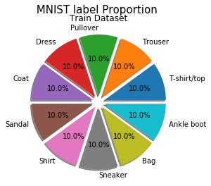

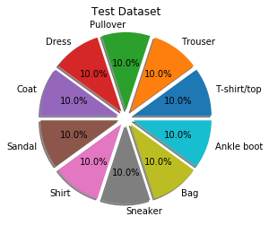

```python
#proportion of data mnist train data

#total number of train labels
train_n=mnist_train_labels.shape[0]

#the purcentage of each label in the training data set
mnist_train_fracs=[len(mnist_train_labels[np.where(mnist_train_labels==i)])*100/train_n for i in range(10)]

#total number of test labels which is the same as train_n
test_n=mnist_test_labels.shape[0]

#the purcentage of each label in the test data set
mnist_test_fracs=[len(mnist_test_labels[np.where(mnist_test_labels==i)])*100/train_n for i in range(10)]


#ploting the results into a pie

grid = GridSpec(1, 1)

#each element of this list defines how far the portion should get from the cercle center
explode = [0.1 for i in range(10)]

#the aspect here is equal to 1 which means the pie is a perfect circle
ax=plt.subplot(grid[0, 0], aspect=1)

#figure configuration for train dataset
plt.suptitle(" MNIST label Proportion\n",fontsize=15)
ax.set_title("Train Dataset")
plt.pie(mnist_train_fracs, explode=explode, labels=labels_mnist, autopct='%.1f%%', shadow=True, radius=1)
plt.show()

#figure configuration for test dataset
ax1=plt.subplot(grid[0, 0], aspect=1)
ax1.set_title("Test Dataset")
plt.pie(mnist_test_fracs, explode=explode, labels=labels_mnist, autopct='%.1f%%', shadow=True,radius=1)
plt.show()
```

### III.2 cifar10 dataset Go to content Table

### Sample Visualisation

```python
#list of the cifar10 labels
labels_cifar10=[
    "airplane",
    "automobile",
    "bird",
    "cat",
    "deer",
    "dog",
    "frog",
    "horse",
    "ship",
    "truck"
    ]
```

```python
#reformating and reshaping the data into (32,32,3) image matrix for visualisation puposes
cifar10_train_data_f = cifar10_train_data.reshape(cifar10_train_data.shape[0],3,32,32)
cifar10_train_data_f=np.array([row.transpose((1,2,0)) for row in cifar10_train_data_f])

cifar10_test_data_f = cifar10_test_data.reshape(cifar10_test_data.shape[0],3,32,32)
cifar10_test_data_f=np.array([row.transpose((1,2,0)) for row in cifar10_test_data_f])
```

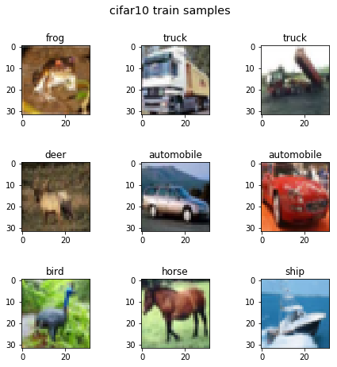

```python
#Plotting cifar10_train_data first 9 samples
plot_cifar10_first_samples(cifar10_train_data_f,cifar10_train_labels,labels_cifar10,"train")
```

[figure not shown]

```python
#Plotting cifar10_test_data first 9 samples
plot_cifar10_first_samples(cifar10_test_data_f,cifar10_test_labels,labels_cifar10,"test")
```

### Cifar10 label distribution

In addition to the pie graph, here is an other way to see the distribution of the data!

```
Text(0.5,0.98,'Cifar10 label distribution')
```

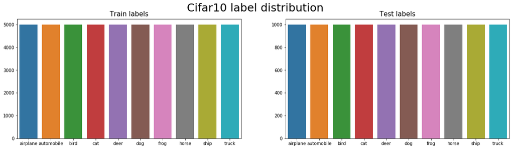

```python
#list of each train label total number
cifar10_train_labels_distribution=[list(cifar10_train_labels).count(l) for l in range(10)]

#list of each test label total number
cifar10_test_labels_distribution=[list(cifar10_test_labels).count(l) for l in range(10)]



#ploting the results into a bar plot

fig, axs = plt.subplots(1,2, figsize = (20,5))

sns.barplot(x=labels_cifar10, y=cifar10_train_labels_distribution, ax=axs[0] )
sns.barplot(x=labels_cifar10, y=cifar10_test_labels_distribution, ax=axs[1] )

axs[0].set_title('Train labels',fontsize=15)
axs[1].set_title('Test labels',fontsize=15)

plt.suptitle("Cifar10 label distribution",fontsize=25)
```

### Question 2:

**Comment on the distribution of class labels and the dimensionality of the input and how these may affect the analysis.**  
The `MIST` dataset is divided into a training set of 60,000 samples of images of dimension 28*28 and a test set of 10,000 samples.  
The `CIFAR10` dataset consists of 60000 32x32 colour images in 10 classes, with 6000 images per class. There are 50000 training images and 10000 test images:  
*-* These huge dimensions may have a significant impact on the computation time and memory overflow.  
*- The class labels are equally distributed in both datasets for both train and test sets.  
To see how this is benificial let's take a quick example: imagine instead of 5000 `dogs` we only have around 500 and the remaining spots are equally distributed between the other labels. The `dog` label data will be considered as noise or an outlier, since it's so small compared to the other numbers of labels. Moreover, this may lead to overfitting, because the classifier will fit into those data and won't be able to act well when given a new dataset.

# IV. Naïve Bayes Classifier Go to content Table

A Naïve Bayes classifier is probabilistic classifier based on applying Bayes' rule with independence assumptions between the features.
** What the logic behind this algorithm?** Let's say we have a data sample represented by the vector **x<sub>new</sub>** = (x<sub>1</sub>,...,x<sub>n</sub>), that we want to classify.
We will assign to this sample a set of probabilities P(t<sub>new</sub>=k|x<sub>1</sub>,...,x<sub>n</sub>) = P(t<sub>new</sub>=k|**x<sub>new</sub>**). For each k, P(t<sub>new</sub>=k|**x<sub>new</sub>**) is the probability that the sample has a label `k`.
After computing those probabilities, we assign P(t<sub>new</sub>=i|**x<sub>new</sub>**) = max{P(t<sub>new</sub>=1|**x<sub>new</sub>**),P(t<sub>new</sub>=2|**x<sub>new</sub>**),...,P(t<sub>new</sub>=k|**x<sub>new</sub>**)}, to our sample, ie the label of **x<sub>new</sub>** is `i`.
**And how do we implement P(t<sub>new</sub>=k|**x**)? **
We simply use **Bayes' rule: ** $$P(t_{new}=k\mid X,t,x_{new}) = \frac{P(x_{new}\mid t_{new}=k, X, t)P(t_{new}=k)}{\sum_j p(x_{new}\mid t_{new}=j,X,t)P(t_{new}=j)}$$
And we should not forget about the assumption of the indepence of the features of **x<sub>new</sub>**, ie $$P(x_{new}\mid t_{new}=k,X,t) = \prod_{d=1}^Dp(x^{new}_d\mid t_{new}=k,X,t)$$ where $D$ is the number of dimensions and $x_d^{new}$ is the valued of $d^{th}$ one.
Since the normal distribution is friendly, let's alsp assume that: $$p(x^{new}_d\mid t_{new}=k,X,t)= N({\bf{\mu_{kd},\sigma_{kd}^2}})$$
**What about the prior?**
$P(t_{new}=k)$ doesn't depend on $x_{new}$ so let's just take the uniform distribution for this guy!
Let's implement the Naïve Bayes Classifier and apply it to our previous datasets.

### IV.1 Implementation Go to content Table

```python
def log_normal(X, mu,var):
    dist=-0.5 * (np.sum((np.log(2. * np.pi * var))+((X - mu)**2) / var,1))
    return dist


def fitting(X,K):
    print("Starting fitting ...")
    mu=[]
    s2=[]
    prior=[]
    for d in range(K):
        #print("d=",d)
        prior.append(1/K)
        X_d=np.array(X[np.where(X[:,0]==d)][:,1:])
        #print("X_d.shape",X_d.shape)
        mu.append(np.mean(X_d,axis=0))

        var=np.var(X_d,axis=0)
        for i in range(X.shape[1]-1):
            if var[i]<=0:
                var[i]= 1e-5

        s2.append(var)
    prior=np.array(prior)
    mu=np.array(mu)
    s2=np.array(s2)

    #print("X.shape",X.shape)
    print("Fitting successful!\n")

    return prior,mu,s2

def predictions(t,X,prior,mu,s2,K):
    print("Starting prediction ...")

    p_t=[]

    for i in range (K):
        p_x=log_normal(X,mu[i],s2[i])
        p_t.append(p_x+np.log(prior[i]))

    p_t=np.array(p_t)

    t_new=np.argmax(p_t, axis=0).reshape(-1,1)
    loss_l = log_loss(y_true=t, y_pred=p_t.T)
    accuracy = accuracy_score(t,t_new)
    print("Prediction successful!\n")
    return t_new, loss_l, accuracy
```

### Question 3.b :

** Describe a positive and a negative feature of the classifier for these tasks**  
** Positive feature **  
It's fast in computation and make easy to implement. In fact, the independency assumption between the features is very powerful especially when it comes to high dimensional uncorrelated data.  
** Negative feature **  
This blessing might be a curse in some cases. In fact this assumption might be wrong when it comes to correlated data, or not big dimensions therefore this may lead to a very bad performance.

### Question 3.c :

** Describe any data pre-processing that you suggest for this data and your classifier**  
For these specific data, I would suggest:  
**-** Binarization for the MNIST dataset. In fact, since the images are gray, we might think about transforming the pixels into 0 or 1 instead of of a value in [0,255]. This may lead to loose some information but it makes the contrast higher which might actually be helpful to identify the pattern in the image during the learning and the prediction as well. It goes without saying that the computational time will decrease.  
**-** The CIFAR10 dataset is bigger than the MNIST dataset since the images have extra information about the colors. each pixel has 3 colors between 0 and 255. This corresponds to the RGB standard! We think about normalizing those value.  
*-* An other general technique consists in removing highly correlation items and dealing with outliers.

### IV.2 Application to Fashion MNIST dataset Go to content Table

### Fitting and computing predictions

```python
mnist_test_labels.shape
```

```
(10000,)
```

```python
#number of classes, which is the number of labels in our case
K=10

#fitting the data and computing the prior, the mean and the variance
mnist_train_X=np.hstack((mnist_train_labels.reshape(-1,1),mnist_train_data))
prior,mu,s2=fitting(mnist_train_X,K)

#Calculte the predictions and computing the logarithmic loss and the accuracy of the model
mnist_test_X=mnist_test_data
mnist_predictions, mnist_loss_l, mnist_accuracy =predictions(mnist_test_labels,mnist_test_X,prior,mu,s2,K)


print ("{: ^100s}".format("------------------Naive Bayes Performance for mnist dataset----------------------------"))
print("\t\t\tAccuracy :\t\t==>",round(mnist_accuracy * 100, 3),"%")
print("\t\t\tlogarithmic loss :\t==>", round(mnist_loss_l, 3))
print ("{: ^100s}".format("---------------------------------------------------------------------------------------"))
```

```
Starting fitting ...
Fitting successful!

Starting prediction ...
Prediction successful!

      ------------------Naive Bayes Performance for mnist dataset----------------------------
			Accuracy :		==> 59.14 %
			logarithmic loss :	==> 2.303
      ---------------------------------------------------------------------------------------
```

```python
mnist_train_X.shape
```

```
(60000, 785)
```

### IV.3 Application to CIFAR10 dataset Go to content Table

```python
#number of classes, which is the number of labels in our case
K=10

#fitting the data and computing the prior, the mean and the variance
cifar10_train_X=np.hstack((cifar10_train_labels.reshape(-1,1),cifar10_train_data))
prior,mu,s2=fitting(cifar10_train_X,K)

#Calculte the predictions and computing the logarithmic loss and the accuracy of the model
cifar10_test_X=cifar10_test_data
cifar10_predictions, cifar10_loss_l, cifar10_accuracy =predictions(cifar10_test_labels,cifar10_test_X,prior,mu,s2,K)


print ("{: ^100s}".format("------------------Naive Bayes Performance for cifar10 dataset----------------------------"))
print("\t\t\tAccuracy :\t\t==>",round(cifar10_accuracy * 100, 3),"%")
print("\t\t\tlogarithmic loss :\t==>", round(cifar10_loss_l, 3))
print ("{: ^100s}".format("---------------------------------------------------------------------------------------"))
```

```
Starting fitting ...
Fitting successful!

Starting prediction ...
Prediction successful!

     ------------------Naive Bayes Performance for cifar10 dataset----------------------------
			Accuracy :		==> 29.76 %
			logarithmic loss :	==> 2.303
      ---------------------------------------------------------------------------------------
```

### IV.4 confusion Matrices Go to content Table

### confusion Matrix function

```python
def confusionMatrix(y_true, y_pred,title,features):
    matrix=confusion_matrix(y_true, y_pred)

    f, ax = plt.subplots(figsize = (10,10))
    sns.heatmap(matrix, annot=True,fmt='.0f', cmap='Blues', square=True) #cmap='Blues'
    ax.set_title(title)
    ax.set_xticklabels(features, rotation=30)
    ax.set_yticklabels(features, rotation=0)
```

### mnist confusion Matrix display

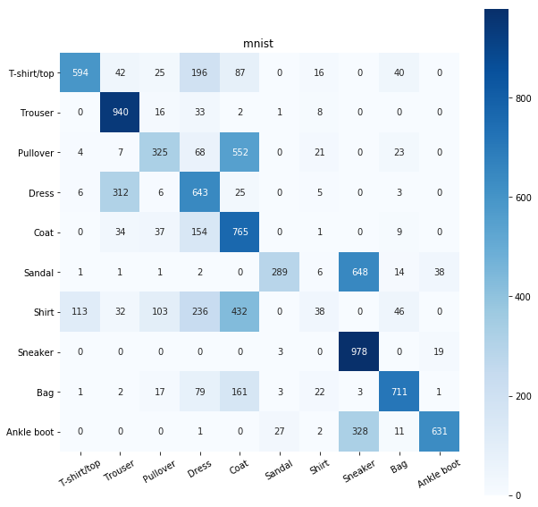

```python
confusionMatrix(mnist_test_labels, mnist_predictions,"mnist ",labels_mnist)
```

### cifar10 confusion Matrix display

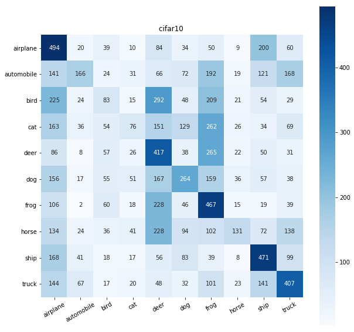

```python
confusionMatrix(cifar10_test_labels, cifar10_predictions,"cifar10 ",labels_cifar10)
```

### IV.5 Performance analysis Go to content Table

### Comparaison with random classification

```python
#generating a prediction output for mnist dataset based on a random choice of labels for each row
mnist_random_classification=np.array([random.randint(0, K) for i in range(len(mnist_test_X))])

#computing the accuracy given the true prediction vector which is mnist_test_labels
mnist_random_accuracy = accuracy_score(mnist_test_labels,mnist_random_classification)

print ("{: ^100s}".format("---------------Accuracy of Random Classification for mnist dataset-------------------------"))
print("\t\t\tmnist Accuracy :\t==>",round(mnist_random_accuracy * 100, 3),"%")
print ("{: ^100s}".format("-------------------------------------------------------------------------------------------"))
```

```
    ---------------Accuracy of Random Classification for mnist dataset-------------------------
			mnist Accuracy :	==> 8.99 %
    -------------------------------------------------------------------------------------------
```

```python
#generating a prediction output for cifar10 dataset based on a random choice of labels for each row
cifar10_random_classification=np.array([random.randint(0, K) for i in range(len(cifar10_test_X))])

#computing the accuracy given the true prediction vector which is cifar10_test_labels
cifar10_random_accuracy = accuracy_score(cifar10_test_labels,cifar10_random_classification)

print ("{: ^100s}".format("---------------Accuracy of Random Classification for cifar10 dataset-------------------------"))
print("\t\t\tcifar10 Accuracy :\t==>",round(cifar10_random_accuracy * 100, 3),"%")
print ("{: ^100s}".format("-------------------------------------------------------------------------------------------"))
```

```
   ---------------Accuracy of Random Classification for cifar10 dataset-------------------------
			cifar10 Accuracy :	==> 8.98 %
    -------------------------------------------------------------------------------------------
```

### How to improve the performance of our classifier

### Question 3.f :

** Discuss the performance, compare them against a classifier that outputs random class labels, and suggest ways in which performance could be improved**  
**-** Clearly the random classifier have a really poor performance, which is arround 10%. This matches The the implementation, since given a big number of features the random generator has almost a uniform distribution.  
**-** On the other hand, the accuracy of the Naïve Bayes Classifier with the MNIST dataset is $59.14$%, and it's $29,76$% with the CIFAR10 dataset. Those accuracies don't make the Naïve Bayes Classifier reliable to do a good classification. This might be improved by taking into account the optimizations listed above, binarization for instance.

# V. Bayesian Linear Regression Go to content Table

**-**Bayesian Linear Regression is based on the Bayes rule:
$$ p(w \mid X,t) = \frac{p(t\mid X,w) p(w)}{p(t\mid X)} $$
**-**In order to find computer the $posterior (p(w \mid X,t))$, we need first to define the **likelihood** and **the prior**.
**-**For the **likelihood**, we use the **gaussian likelihood**:
$$p(t \mid w, X, \sigma^2) = N(Xw, \sigma^2I)$$
**-**Since the prior is conjugated to the likelihood, that means we get to choose a gaussian distribution for the prior as well:
$$p(w) = N(0,S)$$
As a result, the posterior density is also a gaussian:
$$N(\mu, \Sigma)$$
**-**After some mathematic calculations we find:
$$ \Sigma = (\frac{1}{\sigma^2}X^TX + S^{-1})^{-1}$$ and $$ \mu = \frac{1}{\sigma^2}\Sigma X^Tt $$
**-**After fitting the model and finding the parameters for the posterior, prediction is computed, under the linearity assumption, as follows: $$t_{new}=X\mu$$ **NB:** The more the model is complex the closer the predictions during the training phase, so it seems to be a good idea to add polynomial features of order K that will be tuned according to the performance of the model.
**-**Let's implement the Bayesian Linear Regression and apply it to our previous datasets.

### V.1 Implementation Go to content Table

```python
from numpy.linalg import inv
from sklearn.metrics import mean_squared_error as mse
def set_X(x,k):
    print("starting setting X matrix ...")
    X=np.ones(x.shape[0]).reshape(-1,1)
    #print("X.shape",X.shape)
    #print("x.shape",x.shape)

    for i in range (k):
        #print("i",i)
        X=np.hstack((X,np.power(x,i+1)))
    print("X matrix is successful!\n")
    return X

def posterior(X,t):
    print("starting computing the posterior ...")
    I=np.identity(X.shape[1])
    w=np.dot(inv(np.dot(X.T,X)),np.dot(X.T,t))
    s2=np.dot((t-np.dot(X,w)).T,(t-np.dot(X,w)))/len(t)

    sigma= inv((np.dot(X.T,X)/s2+I))
    mu= np.dot(sigma,np.dot(X.T,t))/s2

    print("posterior successful!\n")
    return sigma, mu

def predict(x,t,x_new,t_new, k):
    print("starting prediction ...\n")
    X=set_X(x,k)
    X_new=set_X(x_new,k)

    sigma,mu=posterior(X,t)

    t_pred=np.dot(X_new,mu)
    t_label_pred=np.array([min(max(round(p),0),9) for p in t_pred])
    accuracy=accuracy_score(t_label_pred,t_new)
    error=mse(t_pred,t_new)
    print("prediction successful! \n")
    return t_pred, t_label_pred, accuracy, error
```

### V.2 Application to Fashion mnist dataset Go to content Table

```python
#Polynom order in x
K=3

(x,t,x_new,t_new) = (mnist_train_data,
                        mnist_train_labels,
                        mnist_test_data,
                        mnist_test_labels
                    )

'''
Calculating the continuous predictions: `mnist_predictions`, the corresponding
label number: `mnist_label_predictions` and computing the accuracy as well as the mean square error
'''
mnist_predictions,mnist_label_predictions, mnist_accuracy, mnist_mse=predict(x,t,x_new,t_new, K)


print ("{: ^100s}".format("------------------Bayesian Linear Regression Performance for mnist dataset----------------------------"))
print("\t\t\tAccuracy :\t\t==>",round(mnist_accuracy * 100, 3),"%")
print("\t\t\tmean square error :\t==>", round(mnist_mse, 3))
print ("{: ^100s}".format("---------------------------------------------------------------------------------------"))
```

```
starting prediction ...

starting setting X matrix ...
X matrix is successful!

starting setting X matrix ...
X matrix is successful!

starting computing the posterior ...
posterior successful!

prediction successful!

------------------Bayesian Linear Regression Performance for mnist dataset----------------------------
			Accuracy :		==> 45.27 %
			mean square error :	==> 1.732
      ---------------------------------------------------------------------------------------
```

### V.3 Application to Fashion CIFAR10 dataset Go to content Table

```python
#Polynom order in x
K=3
(x,t,x_new,t_new, k) = (cifar10_train_data,
                        cifar10_train_labels,
                        cifar10_test_data,
                        cifar10_test_labels,
                        K)

'''
Calculating the continuous predictions: `cifar10_predictions`, the corresponding
label number: `cifar10_label_predictions` and computing the accuracy as well as the mean square error.
'''

cifar10_predictions,cifar10_label_predictions, cifar10_accuracy, cifar10_mse=predict(x,t,x_new,t_new, K)

print ("{: ^100s}".format("------------------Bayesian Linear Regression Performance for cifar10 dataset----------------------------"))
print("\t\t\tAccuracy :\t\t==>",round(cifar10_accuracy * 100, 3),"%")
print("\t\t\tmean square error :\t==>", round(cifar10_mse, 3))
print ("{: ^100s}".format("---------------------------------------------------------------------------------------"))
```

```
starting prediction ...

starting setting X matrix ...
X matrix is successful!

starting setting X matrix ...
X matrix is successful!

starting computing the posterior ...
posterior successful!

prediction successful!

------------------Bayesian Linear Regression Performance for cifar10 dataset----------------------------
			Accuracy :		==> 12.16 %
			mean square error :	==> 9.138
      ---------------------------------------------------------------------------------------
```

### V.4 Scatter plot Go to content Table

### mnist scatter plot

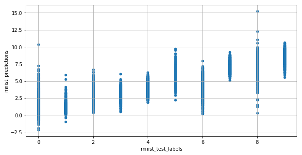

```python
#creating a DataFrame for visualisation purposes
data = pd.DataFrame({"mnist_predictions":mnist_predictions,"mnist_test_labels":mnist_test_labels})

#Plotting the scatter graph
fig, axs = plt.subplots( figsize = (10,5))
data.plot(x='mnist_test_labels', y='mnist_predictions', kind='scatter', ax=axs)
plt.grid()
plt.show()
```

### cifar10 scatter plot

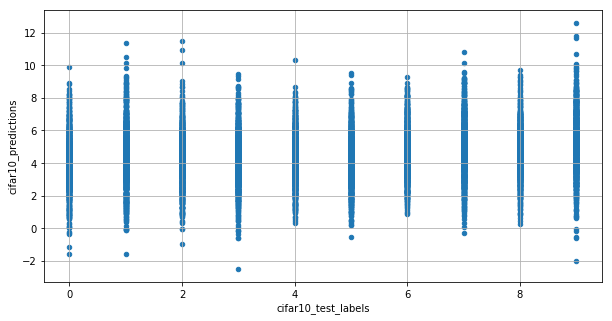

```python
data = pd.DataFrame({"cifar10_predictions":cifar10_predictions,"cifar10_test_labels":cifar10_test_labels})
fig, axs = plt.subplots( figsize = (10,5))
data.plot(x='cifar10_test_labels', y='cifar10_predictions', kind='scatter', ax=axs)

plt.grid()
plt.show()
```

### V.5 Confusion Matrices Go to content Table

### Bayesian Linear Regression: mnist confusion Matrix display

[figure not shown]

```python
confusionMatrix(mnist_test_labels, mnist_label_predictions,"cifar10 ",labels_mnist)
```

### cifar10 confusion Matrix display

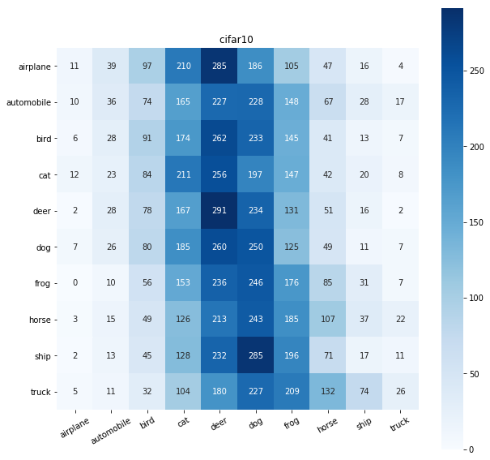

```python
confusionMatrix(cifar10_test_labels, cifar10_label_predictions,"cifar10 ",labels_cifar10)
```

### Question 4.d :

** Suggest a way to discretize predictions and display the confusion matrix on the test data and report accuracy**  
*-* since a probability distribution is used in order to generate a prediction vertor with float values that are supposed to be slightly moved away from the label number, the best way to discretize predictions is to replace every float by the closest integer which will be the label. *-* The negative values are replaced with $0$ and those which are greater than 9 are replaced by 9.

### Question 4.e :

** Discuss regression performance with respect to classification performance**  
**Naïve Bayes Classifier:**  
``` MNIST: 59.14% CIFAR10: 29.76% ```  
**Bayesian Linear Regression:**  
``` MNIST: 45.27% CIFAR10: 12.16% ```  
*-* The Naïve Bayes Classifier has more accuracy than the Bayesian Linear Regression model in both datasets.  
*-* The classification approach is based on a probabilistic model with the assumption of the indepency of the input data, which is tolerated compared to the linear regression assumption. In fact, this model is based on the relation $t=X*w$ which is the consequence of the linearity assumption between the data X and the labels t. In our specific case, the target contains values between 0 and 9 which is definitely not in a linear relationship with the set of pixel values. Therefore, this explains the poor accuracy of Bayesian Linear Regression.

### Question 4.f :

** Describe one limitation of using regression for this particular task**  
*-* One main limitation of regression is the linear assumption which is clearly not the best way to describe the real model which leads to bad accuracy.

# VI. Bonus question Go to content Table

### VI.1 MNIST dataset: CNN output Go to content Table

```python
import keras
from keras.datasets import mnist
from keras.models import Sequential
from keras.layers import Dense, Dropout, Flatten
from keras.layers import Conv2D, MaxPooling2D
from keras import backend as K
from keras.models import Model

batch_size = 128
num_classes = 10
epochs = 12

# input image dimensions
img_rows, img_cols = 28, 28

# the data, split between train and test sets
#(x_train, y_train), (x_test, y_test) = mnist.load_data()

x_train=mnist_train_data
y_train=mnist_train_labels
x_test=mnist_test_data
y_test=mnist_test_labels


if K.image_data_format() == 'channels_first':
    x_train = x_train.reshape(x_train.shape[0], 1, img_rows, img_cols)
    x_test = x_test.reshape(x_test.shape[0], 1, img_rows, img_cols)
    input_shape = (1, img_rows, img_cols)
else:
    x_train = x_train.reshape(x_train.shape[0], img_rows, img_cols, 1)
    x_test = x_test.reshape(x_test.shape[0], img_rows, img_cols, 1)
    input_shape = (img_rows, img_cols, 1)

x_train = x_train.astype('float32')
x_test = x_test.astype('float32')
x_train /= 255
x_test /= 255
print('x_train shape:', x_train.shape)
print(x_train.shape[0], 'train samples')
print(x_test.shape[0], 'test samples')

# convert class vectors to binary class matrices
y_train = keras.utils.to_categorical(y_train, num_classes)
y_test = keras.utils.to_categorical(y_test, num_classes)

# model creation and definition
model = Sequential()
model.add(Conv2D(32, kernel_size=(3, 3),
                 activation='relu',
                 input_shape=input_shape))
model.add(Conv2D(64, (3, 3), activation='relu'))
model.add(MaxPooling2D(pool_size=(2, 2)))
model.add(Dropout(0.25))
model.add(Flatten(name='flatten_layer'))
model.add(Dense(128, activation='relu'))
model.add(Dropout(0.5))
model.add(Dense(num_classes, activation='softmax'))

# model Compilation
model.compile(loss=keras.losses.categorical_crossentropy,
              optimizer=keras.optimizers.Adadelta(),
              metrics=['accuracy'])

# Fitting the model
model.fit(x_train, y_train,
          batch_size=batch_size,
          epochs=epochs,
          verbose=1,
          validation_data=(x_test, y_test))

# evaluating  the model
score = model.evaluate(x_test, y_test, verbose=0)
print('Test loss:', score[0])
print('Test accuracy:', score[1])
```

```
x_train shape: (60000, 28, 28, 1)
60000 train samples
10000 test samples
Train on 60000 samples, validate on 10000 samples
Test loss: 0.18863180019557477
Test accuracy: 0.9318
```

### VI.2 Applying Naïve Bayes Classifier Go to content Table

```python
# choose the layer just before the first fully connected layer
flat_model = Model(inputs = model.input, outputs = model.get_layer('flatten_layer').output)
cnn_train = flat_model.predict(x_train)
cnn_test = flat_model.predict(x_test)
```

```python
#adding the labels for the fitting
cnn_train=np.hstack((mnist_train_labels.reshape(-1,1),cnn_train))
```

```python
K=10
cnn_prior,cnn_mu,cnn_s2=fitting(cnn_train,K)
```

```
Starting fitting ...
Fitting successful!
```

```python
print("cnn_train.shape",cnn_train.shape)
print("cnn_test.shape",cnn_test.shape)
```

```
cnn_train.shape (60000, 9217)
cnn_test.shape (10000, 9216)
```

```python
cnn_mnist_predictions, cnn_mnist_loss_l, cnn_mnist_accuracy =predictions(mnist_test_labels,cnn_test,cnn_prior,cnn_mu,cnn_s2,K)
```

```
Starting prediction ...
Prediction successful!
```

```python
print ("{: ^100s}".format("------------------CNN Naive Bayes Performance for mnist dataset----------------------------"))
print("\t\t\tAccuracy :\t\t==>",round(cnn_mnist_accuracy * 100, 3),"%")
print("\t\t\tlogarithmic loss :\t==>", round(cnn_mnist_loss_l, 3))
print ("{: ^100s}".format("---------------------------------------------------------------------------------------"))
```

```
    ------------------CNN Naive Bayes Performance for mnist dataset----------------------------
			Accuracy :		==> 77.18 %
			logarithmic loss :	==> 1.758
      ---------------------------------------------------------------------------------------
```

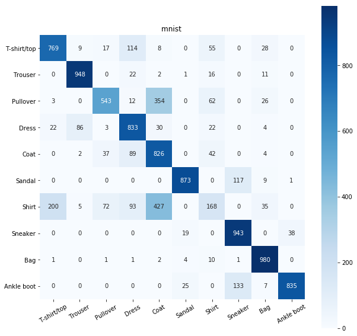

```python
confusionMatrix(mnist_test_labels, cnn_mnist_predictions,"mnist ",labels_mnist)
```

### INFERENCE

Applying the Naive Bayes Classifier to the output of the the CNN applied on the MNIST dataset has clearly a huge progress in terms of accuracy. In fact,  
**Naïve Bayes Classifier (Before)**  
``` MNIST: 59.14% ```  
**CNN Naïve Bayes Classifier (After)**  
``` MNIST: 77.18 % ``` This means that the Naive Bayes Classifier is not that bad after all, as soon as we feed him with good and well processed data.